# Homework 06

## Question 1: Compare KNN and logistic regression

Use breast-cancer.csv, which contains 569 cases from the [Wisconsin Diagnostic Breast Cancer dataset](https://archive.ics.uci.edu/dataset/17/breast%2Bcancer%2Bwisconsin%2Bdiagnostic). Predict `y` (1 for malignant and 0 for benign) using `mean_radius`, `mean_texture`, and `mean_smoothness`.

Set a random seed and randomly split the observations into 70% training and 30% test data. Use the same split for every model. Standardize the predictors using the training means and standard deviations, and apply the same transformations to the test data.

Fit ordinary logistic regression with an intercept and no penalty, and KNN with Euclidean distance, equal neighbor weights, and

$$k\in\{5,15,25,35,45\}.$$

Using the estimated probabilities for `y = 1` on the test data, plot all six ROC curves in one figure and report their AUC values. Which of the six fitted models do you prefer? Give a brief justification based on your results.

```r
library(tidyverse)
library(class)
library(pROC)

# Load the data
breast_cancer <- read_csv(
  "C:/Users/melik/Documents/UIUC/courses/STAT432 - Zhu/homework/week-06/data/breast-cancer.csv",
  show_col_types = FALSE
)

# Randomly split the data into training and test sets
set.seed(432)
train_index <- sample(
  seq_len(nrow(breast_cancer)),
  size = floor(0.70 * nrow(breast_cancer))
)

train_data <- breast_cancer[train_index, ]
test_data <- breast_cancer[-train_index, ]

# Standardize predictors using only the training data
predictor_names <- c("mean_radius", "mean_texture", "mean_smoothness")
train_means <- sapply(train_data[predictor_names], mean)
train_sds <- sapply(train_data[predictor_names], sd)

train_x <- scale(
  train_data[predictor_names],
  center = train_means,
  scale = train_sds
)
test_x <- scale(
  test_data[predictor_names],
  center = train_means,
  scale = train_sds
)

train_y <- train_data$y
test_y <- test_data$y

# Fit OLS using the standardized predictors
train_x <- as.data.frame(train_x)
test_x <- as.data.frame(test_x)
ols_fit <- lm(y ~ ., data = cbind(y = train_y, train_x))
ols_test_probabilities <- as.numeric(predict(ols_fit, newdata = test_x))

# Fit KNN models using the same training/test split
k_values <- c(5, 15, 25, 35, 45)
knn_probabilities <- map_dfc(k_values, function(k) {
  knn_predictions <- knn(
    train = train_x,
    test = test_x,
    cl = factor(train_y, levels = c(0, 1)),
    k = k,
    prob = TRUE
  )
  winning_probability <- attr(knn_predictions, "prob")
  ifelse(knn_predictions == "1", winning_probability, 1 - winning_probability)
}) |>
  set_names(paste0("KNN (k = ", k_values, ")"))

# Calculate ROC curves and AUC values on the test data
model_probabilities <- c(
  list(OLS = ols_test_probabilities),
  as.list(knn_probabilities)
)

roc_curves <- map(
  model_probabilities,
  ~ roc(response = test_y, predictor = .x, quiet = TRUE, direction = "<")
)

auc_values <- tibble(
  model = names(roc_curves),
  auc = map_dbl(roc_curves, ~ as.numeric(auc(.x)))
) |>
  arrange(desc(auc))

auc_values
```

```
# A tibble: 6 × 2
  model          auc
  <chr>        <dbl>
1 KNN (k = 45) 0.974
2 OLS          0.974
3 KNN (k = 35) 0.973
4 KNN (k = 25) 0.960
5 KNN (k = 15) 0.948
6 KNN (k = 5)  0.933
```

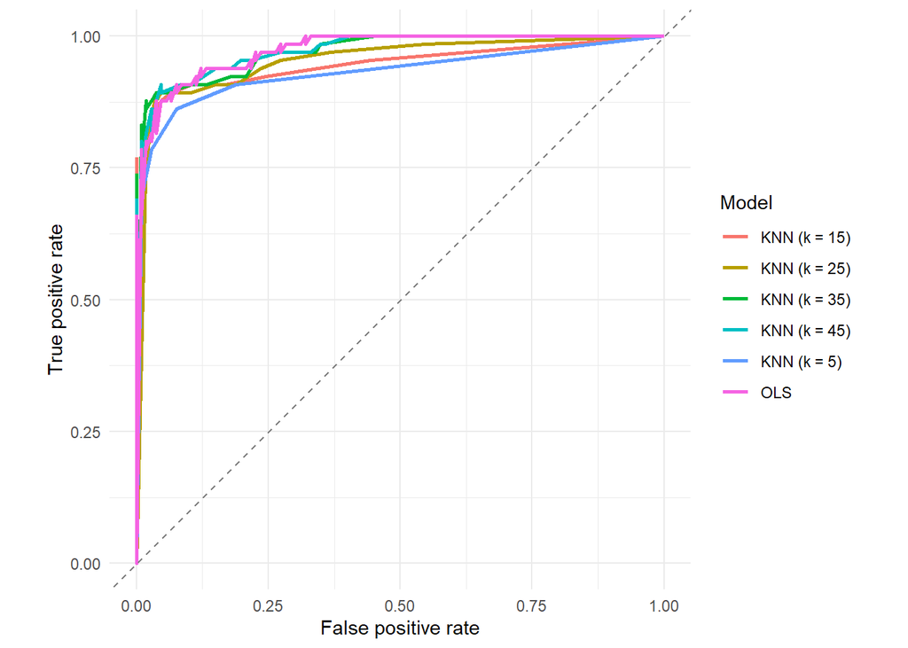

Test-set ROC curves for OLS and KNN models.

```r
roc_plot_data <- imap_dfr(roc_curves, function(roc_curve, model_name) {
  tibble(
    false_positive_rate = 1 - roc_curve$specificities,
    true_positive_rate = roc_curve$sensitivities,
    model = model_name
  )
})

ggplot(roc_plot_data, aes(false_positive_rate, true_positive_rate, color = model)) +
  geom_line(linewidth = 1) +
  geom_abline(
    slope = 1,
    intercept = 0,
    linetype = "dashed",
    color = "gray50"
  ) +
  coord_equal() +
  labs(
    x = "False positive rate",
    y = "True positive rate",
    color = "Model"
  ) +
  theme_minimal()
```

The largest test-set AUC is achieved by both OLS and KNN with (k=45), with an AUC of approximately 0.974. Therefore, these are the two preferred models based on predictive discrimination. KNN with (k=35) performs nearly as well, with an AUC of approximately 0.973, while the smaller KNN values perform worse. Because OLS and KNN with (k=45) have essentially the same test-set AUC, I would select OLS as the final model: it is simpler, faster to fit and predict, and easier to interpret, while providing the same observed test-set performance. KNN with (k=45) is a reasonable alternative if a nonparametric model is preferred.

## Question 2: Training and test ROC curves

Use the same data, training/test split, and standardization as in Question 1. Fit KNN with Euclidean distance, equal neighbor weights, and

$$k\in\{1,3,5,10,20\}.$$

Use each fitted model to estimate probabilities for both the training and test observations. For training predictions, include each observation itself among its $k$ nearest neighbors.

For each $k$, use a separate panel to show the training and test ROC curves together. Report both AUC values.

Explain the difference between training and test performance and how it changes with $k$. In particular, explain what happens at $k=1$ and why training performance may not reflect performance on new observations.

Training performance is usually better than test performance because the training observations were used to fit the model. At (k=1), each training observation is its own nearest neighbor, so the training prediction is typically exactly its observed class and the training AUC is close to 1. This is an example of overfitting: excellent training performance does not necessarily imply equally good performance on new observations. Increasing (k) smooths the KNN decision rule, usually lowering training performance but potentially improving generalization to the test data.

```r
# Use the same standardized train/test data and response values as in Q1
q2_k_values <- c(1, 3, 5, 10, 20)

q2_predictions <- map_dfr(q2_k_values, function(k) {
  training_predictions <- knn(
    train = train_x,
    test = train_x,
    cl = factor(train_y, levels = c(0, 1)),
    k = k,
    prob = TRUE
  )
  training_winning_probability <- attr(training_predictions, "prob")
  training_probabilities <- ifelse(
    training_predictions == "1",
    training_winning_probability,
    1 - training_winning_probability
  )

  test_predictions <- knn(
    train = train_x,
    test = test_x,
    cl = factor(train_y, levels = c(0, 1)),
    k = k,
    prob = TRUE
  )
  test_winning_probability <- attr(test_predictions, "prob")
  test_probabilities <- ifelse(
    test_predictions == "1",
    test_winning_probability,
    1 - test_winning_probability
  )

  bind_rows(
    tibble(
      k = k,
      data = "Training",
      truth = train_y,
      probability = training_probabilities
    ),
    tibble(
      k = k,
      data = "Test",
      truth = test_y,
      probability = test_probabilities
    )
  )
})

q2_auc_values <- q2_predictions |>
  group_by(k, data) |>
  summarise(
    auc = as.numeric(auc(roc(truth, probability, quiet = TRUE, direction = "<"))),
    .groups = "drop"
  )

q2_auc_values
```

```
# A tibble: 10 × 3
       k data       auc
   <dbl> <chr>    <dbl>
 1     1 Test     0.876
 2     1 Training 1
 3     3 Test     0.914
 4     3 Training 0.991
 5     5 Test     0.933
 6     5 Training 0.985
 7    10 Test     0.945
 8    10 Training 0.986
 9    20 Test     0.959
10    20 Training 0.988
```

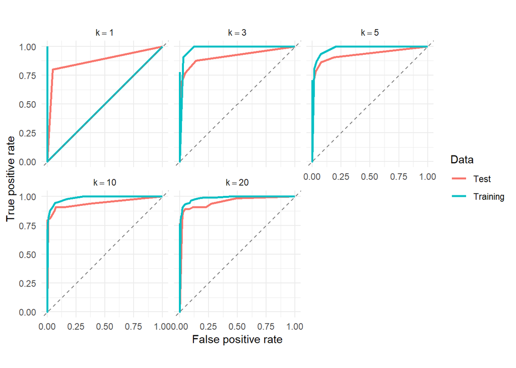

Training and test ROC curves for KNN models with different values of k.

```r
q2_roc_data <- q2_predictions |>
  group_by(k, data) |>
  group_modify(~ {
    roc_curve <- roc(
      response = .x$truth,
      predictor = .x$probability,
      quiet = TRUE,
      direction = "<"
    )
    tibble(
      false_positive_rate = 1 - roc_curve$specificities,
      true_positive_rate = roc_curve$sensitivities
    )
  }) |>
  ungroup()

ggplot(
  q2_roc_data,
  aes(false_positive_rate, true_positive_rate, color = data)
) +
  geom_line(linewidth = 1) +
  geom_abline(
    slope = 1,
    intercept = 0,
    linetype = "dashed",
    color = "gray50"
  ) +
  facet_wrap(~ k, labeller = label_bquote(k == .(k))) +
  coord_equal() +
  labs(
    x = "False positive rate",
    y = "True positive rate",
    color = "Data"
  ) +
  theme_minimal()
```

Overall, the training ROC curves have higher AUC values than the test ROC curves because the KNN models are evaluated on observations used during fitting. The difference is especially large at (k=1): including each observation itself makes the training predictions nearly perfect, but this does not carry over to new observations. As (k) increases, the training curve becomes less extreme because the prediction is averaged over more neighbors. The preferred value of (k) should therefore be based on the test-set AUC rather than the training-set AUC, since test performance better reflects how the model is expected to perform on new data.

## Question 3: Peer evaluation of Homework 5

You will receive two Homework 5 submissions to review. The instructor’s GitHub account, **rqzhu-aide**, will open a **GitHub Issue** in the repository containing your Homework 5 submission. It will contain links to two other students’ repositories, where you can find their submitted homework reports.

Open your repository’s **Issues** tab on GitHub to find the assignment. You may ask AI to explain GitHub Issues or help you locate the assignment.

Choose **one specific mistake or item for improvement** from any question in either report.

1. **Identify the mistake or item for improvement.** State which report and question you selected, and briefly describe what is wrong or could be improved. Examples include incorrect code, a calculation error, a misinterpretation of results, a plot that could communicate the findings more clearly, or anything else you think could be done better.
2. **Explain your assessment.** Quote the relevant text, code, or figure caption exactly. Explain why the selected answer is incorrect or how it could be improved, referring to its reasoning, calculations, code, figures, or interpretation. **Complete this part yourself, without AI assistance.**
3. **Provide a correction.** Write a corrected or improved answer to the selected question, including any calculations, code, or figures needed.

After completing your review, **open a GitHub Issue in the repository containing the report you selected**. Identify the report and question, and include your assessment and a detailed revision plan explaining what the author should change and why. Include a link to your posted GitHub Issue in your Homework 6 answer.

review 1: https://github.com/BothesMTG/stat432-fall2026/issues/2#issue-5705959988  
review 2: https://github.com/ethanmeng2004/stat432-fall2026/issues/3#issue-5706017249